# Presentatoin for Case 31

Sample Presentation

Jae Jung

IBM 3302, Cal Poly Pomona

2025-04-15

# Introduction

- Employees Federal Union (EFCU) is the credit union for a Fortune 500 firm.
- This case illustrates:
  - the entire research process
  - How a presentation can be prepared with enhanced reproducibility
- This case can be used for
  - Introductory marketing research course (R1 - R6)
  - Upper level marketing research course (H1 - H5)

## Problem Definition

- CU has a large amount of surplus fund.
- It has also experienced a lower loan/share ratio than other credit unions of similar size.
- Average earnings on its investments have declined and profit margins are squeezed

## Research Objectives

1. To determine why its members are not borrowing money from the credit union.
2. To determine what the members’ attitudes were toward the overall management and operations of the credit union.

*Notes*: The research objectives were developed by the board

## Significance of Research

- The findings from the research will provide critical information that the management can use to increase loan/ratio rate and increase profit margin.
- Thus, the the research is critical in turning around the company’s struggling financial status.

# Background and Research Questions/Hypotheses

## Information gathering

- To address the research objectives, a research firm was hired.
- The researchers from the consulting company interviewed the management and some customers.
- Based on the qualitative research and the researchers’ own experience, they came up with some research questions and hypotheses.

## Reasons for Consumers’ Use of Credit Union

- What to write on this sub-section?
  - You can use information you learned from academic research
  - You may use white paper available online
  - You can use information you obtained from managers
- Weave the information from various sources to form a logic to support the relationships among the variables in the research question.
- You are labeling it “research question” because you do not have enough evidence to state the relationship with confidence.

**R1**: Why do people join the Credit Union?

## Using services from Other Financial Services

- What to write on this sub-section?
  - You can use information you learned from academic research
  - You may use white paper available online
  - You can use information you obtained from managers
- Weave the information from various sources to form a logic to support the relationships among the variables in the research question.
- You are labeling it “research question” because you do not have enough evidence to state the relationship with confidence.

**R2**: Why do members use other financial institutions when they need to borrow funds?

## Attitudes and beliefs about the employee proficiency

- What to write on this sub-section?
  - You can use information you learned from academic research
  - You may use white paper available online
  - You can use information you obtained from managers
- Weave the information from various sources to form a logic to support the relationships among the variables in the research question.
- You are labeling it “research question” because you do not have enough evidence to state the relationship with confidence.

**R3**: What are the members’ attitudes and beliefs about the proficiencies of credit union employees?

## Differences in Headquarters vs. Elswhere

- What to write on this sub-section?
  - You can use information you learned from academic research
  - You may use white paper available online
  - You can use information you obtained from managers
- Weave the information from various sources to form a logic to support the relationships among the variables in the research question.
- You are labeling it “research question” because you do not have enough evidence to state the relationship with confidence.

**R4**: Are there any perceived differences on attitude towards employee proficiencies, awareness of services, and operational effectiveness between members who live in the area of the firm’s headquarters and members who live elsewhere?

## Awareness of Services

- What to write on this sub-section?
  - You can use information you learned from academic research
  - You may use white paper available online
  - You can use information you obtained from managers
- Weave the information from various sources to form a logic to support the relationships among the variables in the research question.
- You are labeling it “research question” because you do not have enough evidence to state the relationship with confidence.

**R5**: How well are the members aware of the services offered by the credit union?

## CU’s Operational Effectiveness

- What to write on this sub-section?
  - You can use information you learned from academic research
  - You may use white paper available online
  - You can use information you obtained from managers
- Weave the information from various sources to form a logic to support the relationships among the variables in the research question.
- You are labeling it “research question” because you do not have enough evidence to state the relationship with confidence.

**R6**: What are the members’ attitudes and beliefs about how effectively the credit union is operated?

## Adequancy of Finacial Services

- What to write on this sub-section?
  - You can use information you learned from academic research
  - You may use white paper available online
  - You can use information you obtained from managers
- Weave the information from various sources to form a logic to support the relationships among the variables in the research question.
- You are labeling it “Hypothesis” when you have enough evidence to state the relationship with confidence.

**H1**: Members’ `awareness of the regular share accounts` will influence their opinions on the `adequacy of financial services` in meeting members’ needs.

## CU Members’ Opinion on CU’s Loan Rate

- What to write on this sub-section?
  - You can use information you learned from academic research
  - You may use white paper available online
  - You can use information you obtained from managers
- Weave the information from various sources to form a logic to support the relationships among the variables in the research question.
- You are labeling it “Hypothesis” when you have enough evidence to state the relationship with confidence.

**H2**: Members will not be different in their opinion on `CU’s loan rate (Q8r)` and the degree to which they agree that CU’s loan rate is lower than competitors (Q30).

## Impact of Current loan use and residence lcoatoin on Finacial Services Adequacy

- What to write on this sub-section?
  - You can use information you learned from academic research
  - You may use white paper available online
  - You can use information you obtained from managers
- Weave the information from various sources to form a logic to support the relationships among the variables in the research question.
- You are labeling it “Hypothesis” when you have enough evidence to state the relationship with confidence.

**H3a**: There will be interaction effect between the `current loan use` and `location of residence` on adequacy of current financial services such that in headquarter area, members who have a loan will agree, more than those who don’t have, that financial services meet the members’ needs, while in outside headquarter area, loan status doesn’t influence adequacy of financial services in meeting member needs.

**H3b**: Test H2a controlling for the impact of attitudes toward employee proficiency.

## Loan Status and CU Loan Rate

- What to write on this sub-section?
  - You can use information you learned from academic research
  - You may use white paper available online
  - You can use information you obtained from managers
- Weave the information from various sources to form a logic to support the relationships among the variables in the research question.
- You are labeling it “Hypothesis” when you have enough evidence to state the relationship with confidence.

**H4**: Compared with the members who have a loan, those members who don’t have a loan currently with the Credit Union will feel that that CU charges them with higher rates, and that they will agree less with the statement that CU’s loan rates are lower than those offered by other institutions.

## Factors Affecting Attitudes towards Credit Union Operational Efficiency

- What to write on this sub-section?
  - You can use information you learned from academic research
  - You may use white paper available online
  - You can use information you obtained from managers
- Weave the information from various sources to form a logic to support the relationships among the variables in the research question.
- You are labeling it “Hypothesis” when you have enough evidence to state the relationship with confidence.

**H5a**: Member belief about CU keeps personal `financial information confidential` will positively influence the overall attitude toward credit union’s operational efficiency.

**H5b**: `Loan application processing promptness` will positively influence the overall attitude toward credit union’s operational efficiency.

**H5c**: Member `satisfaction with level of financial services in meeting needs` will positively influence the overall attitude toward credit union’s operational efficiency.

**H5d**: `Loan application simplicity and easiness` will positively influence the overall attitude toward credit union’s operational efficiency.

# Methods

## Research Design

- A `mail survey` was used due to the following reasons:
  - CU membership is widely dispersed geographically
  - Low cost
  - Sensitive questions needs anonymity to induce a candid response
  - Long time needed for mail survey is not an issue for the board.
- Questions were mostly `structured` with several key questions asked in `unstructured` format
- `Likert-type` scales were used for attitudes measurements.

## Population and Sampling

- `Population`: All current members of the EFCU.
- `Sampling frame`:
  - A list of members and their addresses is available.
  - 3,531 members as of January 31 for trial balance listing of the EFCU membership
- `Sampling method`: *Simple random sampling*
  - `Sample size`: 300
    - Calculation: was done using estimated`population standard deviation` based on responses of 15 members to Q37.
    - 300 random numbers were generated within the range of 1 to 3,531 members.
    - Each random number was matched with the corresponding number in the sampling frame.

## Data Collection and coding

- Preparatoin of all copies of survey and mailing them were handled by the CU’s staff members.
- The structured questions in the survey were coded based on the classifications established by researchers
- Questionnaire responses were examined for the integrity, and a few responses of low quality were excluded

## Data Preparation

- Used R/RStudio for wrangling and visualization
- Data `wrangling and preparation` was done separately. Specifically, we did the following
  - `Reverse coded`
  - Removed non-responses (`NA`)
  - Removed `Not Applicable responses` from otherwise Likert-type interval scales to make them suitable for continuous variables (e.g., 1-5 piont scale)
  - Renamed variable names
  - Relabeled variable labels and value labels if needed.
  - The prepared data is saved as `Case 31 Data_efcu_Prepped.sav`, which will be used for data analysis.

## Variables in the data

- Number of variables: 54

Data frame: case31

| ID | Name | Label | Values | Value Labels |
| --- | --- | --- | --- | --- |
| 1 | q3 | Employees are Courteous | 1 2 3 4 5 | Strongly Disagree Disagree Uncertain Agree Strongly Agree |
| 2 | q4 | Employees are helpful | 1 2 3 4 5 | Strongly Disagree Disagree Uncertain Agree Strongly Agree |
| 3 | q5 | Employees are professional | 1 2 3 4 5 | Strongly Disagree Disagree Uncertain Agree Strongly Agree |
| 4 | q6 | Employees are available | 1 2 3 4 5 | Strongly Disagree Disagree Uncertain Agree Strongly Agree |
| 5 | q7 | savings rates | 1 2 3 4 5 6 | Very High High Average Low Very Low No Opinion |
| 6 | q8 | statement frequency | 1 2 3 4 5 6 | Very High High Average Low Very Low No Opinion |
| 7 | q9 | statement frequency | 1 2 3 4 5 | Too Often Very Often About Right Not Often Enough Never |
| 8 | q10 | statement accuracy | 1 2 3 4 | Excellent Good Fair Poor |
| 9 | q11 | statement understandable | 1 2 | Yes No |
| 10 | q12 | Account Confidential | 1 2 | Yes No |
| 11 | q13 | regular share account | 1 2 | Aware and Have Used Aware but Have Not Used |
| 12 | q14 | special subaccounts | 1 2 | Aware and Have Used Aware but Have Not Used |
| 13 | q15 | Christmas club account | 1 2 | Aware and Have Used Aware but Have Not Used |
| 14 | q16 | IRA | 1 2 | Aware and Have Used Aware but Have Not Used |
| 15 | q17 | Master credit card | 1 2 | Aware and Have Used Aware but Have Not Used |
| 16 | q18 | signature loans | 1 2 | Aware and Have Used Aware but Have Not Used |
| 17 | q19 | new car loans | 1 2 | Aware and Have Used Aware but Have Not Used |
| 18 | q20 | late model car loans | 1 2 | Aware and Have Used Aware but Have Not Used |
| 19 | q21 | older model car loans | 1 2 | Aware and Have Used Aware but Have Not Used |
| 20 | q22 | household goods loans | 1 2 | Aware and Have Used Aware but Have Not Used |
| 21 | q23 | recreational loans | 1 2 | Aware and Have Used Aware but Have Not Used |
| 22 | q24 | share collateralized loan | 1 2 | Aware and Have Used Aware but Have Not Used |
| 23 | q25 | IRA loans | 1 2 | Aware and Have Used Aware but Have Not Used |
| 24 | q26 | line of credit loans | 1 2 | Aware and Have Used Aware but Have Not Used |
| 25 | q27 | currently have loan | 1 2 | Yes No |
| 26 | q30 | CU rates lower | 1 2 3 4 5 | Strongly Disagree Disagree Uncertain Agree Strongly Agree |
| 27 | q31 | CU confidential | 1 2 3 4 5 | Strongly Disagree Disagree Uncertain Agree Strongly Agree |
| 28 | q32 | CU is prompt | 1 2 3 4 5 | Strongly Disagree Disagree Uncertain Agree Strongly Agree |
| 29 | q33 | CU meets needs of members | 1 2 3 4 5 | Strongly Disagree Disagree Uncertain Agree Strongly Agree |
| 30 | q34 | CU loan applications simple | 1 2 3 4 5 | Strongly Disagree Disagree Uncertain Agree Strongly Agree |
| 31 | q37 | overall rating | 1 2 3 4 5 6 | Excellent Good Average Poor Very Poor No Opinion |
| 32 | overall_employee_performace |  | *range: 2.8-5.0* |  |
| 33 | q38 | headquarter | 1 2 | yes no |
| 34 | employeeperformance |  | *range: 2.8-5.0* |  |
| 35 | at_emp |  | *range: 2.8-5.0* |  |
| 36 | q7r | Savings rates | 1 2 3 4 5 | Very Low Low Average High Very High |
| 37 | q8r | Fund borrowing rates | 1 2 3 4 5 | Very Low Low Average High Very High |
| 38 | q9r | Statement Frequency | 1 2 3 4 5 | Never Not Often Enough About Right Very Often Too Often |
| 39 | q10r | Statement Accuracy | 1 2 3 4 | Poor Fair Good Excellent |
| 40 | q13r | Regular share account | 1 2 3 | Unaware Aware but Have Not Used Aware and Have Used |
| 41 | q14r | Special subaccounts | 1 2 3 | Unaware Aware but Have Not Used Aware and Have Used |
| 42 | q15r | Christmas club account | 1 2 3 | Unaware Aware but Have Not Used Aware and Have Used |
| 43 | q16r | IRA | 1 2 3 | Unaware Aware but Have Not Used Aware and Have Used |
| 44 | q17r | Master credit card | 1 2 3 | Unaware Aware but Have Not Used Aware and Have Used |
| 45 | q18r | Signature loans | 1 2 3 | Unaware Aware but Have Not Used Aware and Have Used |
| 46 | q19r | New car loans | 1 2 3 | Unaware Aware but Have Not Used Aware and Have Used |
| 47 | q20r | Late model car loans | 1 2 3 | Unaware Aware but Have Not Used Aware and Have Used |
| 48 | q21r | Older model car loans | 1 2 3 | Unaware Aware but Have Not Used Aware and Have Used |
| 49 | q22r | Household goods loans | 1 2 3 | Unaware Aware but Have Not Used Aware and Have Used |
| 50 | q23r | Recreational loans | 1 2 3 | Unaware Aware but Have Not Used Aware and Have Used |
| 51 | q24r | Share collateralized loan | 1 2 3 | Unaware Aware but Have Not Used Aware and Have Used |
| 52 | q25r | IRA loans | 1 2 3 | Unaware Aware but Have Not Used Aware and Have Used |
| 53 | q26r | Line of credit loans | 1 2 3 | Unaware Aware but Have Not Used Aware and Have Used |
| 54 | q37r |  | 1 2 3 4 5 | Very Poor Poor Average Good Excellent |

## Sample Characteristics

- Number of participants: 128
- % of the participants who live in the `headquarter area` vs. `non-headquarter area`: 44.5% vs. 55.5%.
- No demographic variables are available on the survey
  - Gender
  - Ethnicity/Race
  - Income
  - Education

## Measures

- Refer to the Construct and Measurement Table.
- All constructs, operationalization, and scales will be provided later.

# Analysis and Results

- Used R for wrangling and modeling

# R1: Overview - One-Sample t-test

**R1: Why do people join the Credit Union?**

- `Constructs and roles`: reasons for why people join the Credit Union
- `Operationalization`: q7r (Savings rates)
- `Scales:`
  - 1-5 point, Likert-type scale
- `Statistics to be used`:
  - Descriptive statistics, followed by one sample t-test

## Descriptive Statistics

### Frequency Distribution

| Savings rates | n | percent |
| --- | --- | --- |
| Very Low | 1 | 0.0078125 |
| Low | 12 | 0.0937500 |
| Average | 83 | 0.6484375 |
| High | 22 | 0.1718750 |
| NA | 10 | 0.0781250 |

Figure 1: Response Frequency of Savings Rate (q7r)

### Descriptive Stat

| vars | n | mean | sd | median | trimmed | mad | min | max | range | skew | kurtosis | se |
| --- | --- | --- | --- | --- | --- | --- | --- | --- | --- | --- | --- | --- |
| 1 | 118 | 3.067797 | 0.5658186 | 3 | 3.067797 | 0 | 1 | 4 | 3 | -0.2645695 | 1.175269 | 0.05208782 |

Figure 2: Descriptive Statistics for Savings Rate (Q7r)

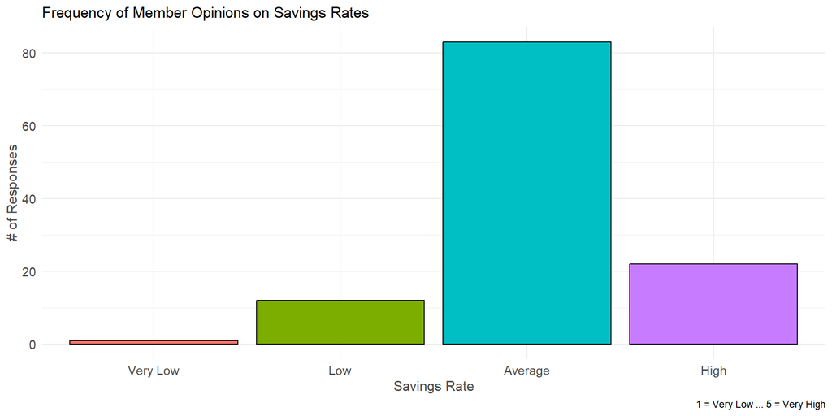

Figure 3: Histogram for Savings Rate (Q7r)

## One-sample t-test

- $H_0: \mu = 3$
- $H_A: \mu \neq 3$

```r
mean_q7r <- case31 |> #count(q7r)
  summarise(mean = mean(q7r, na.rm = TRUE)) |>
  round(2)

case31 |>
  t.test(q7r ~ 1, mu = 3, data = _)
```

```
    One Sample t-test

data:  q7r
t = 1.3016, df = 117, p-value = 0.1956
alternative hypothesis: true mean is not equal to 3
95 percent confidence interval:
 2.964639 3.170954
sample estimates:
mean of x
 3.067797
```

**Insights about R1**

- The majority of the survey participants (`65%`) think that the savings rate the CU offers is average.
- The **`sample mean`** is 3.07, which is not statistically different from 3 (“average”) (*p* > .10).
- Thus, we can conclude that CU members perceive that the savings rate CU applies to them is about average.

# R2: Overview

R2: Why do members use other financial institutions when they need to borrow funds?

- `Constructs and roles`: Reasons to use loans from other financial institutions
- `Operationalization`:
  - q8r (Fund borrowing rates)
  - q30 (CU rates lower)
- `Scales:`
  - 1-5 point, Likert-type scales
- `Statistics to be used`:
  - Descriptive statistics, followed by one sample t-test

# R3: Overview - One-sample t-test

R3: What are the members’ attitudes and beliefs about the proficiency of credit union employees?

- `Constructs and roles`: Attitudes toward employee proficiency
- `Operationalization`:
  - q3, q4, q5, q6 –> at_emp
- `Scale: interval scale`: 1-5 point, Likert-type scale
- `Statistics`:
  - Descriptive statistics
  - Reliabilty/factor analysis,
  - one-sample t-test

## Descriptive Statistics

### Means & SD

```r
describe(case31$at_emp)
```

```
   vars   n mean   sd median trimmed  mad  min max range  skew kurtosis   se
X1    1 128 4.21 0.59      4    4.25 0.74 2.75   5  2.25 -0.32    -0.69 0.05
```

### Histogram

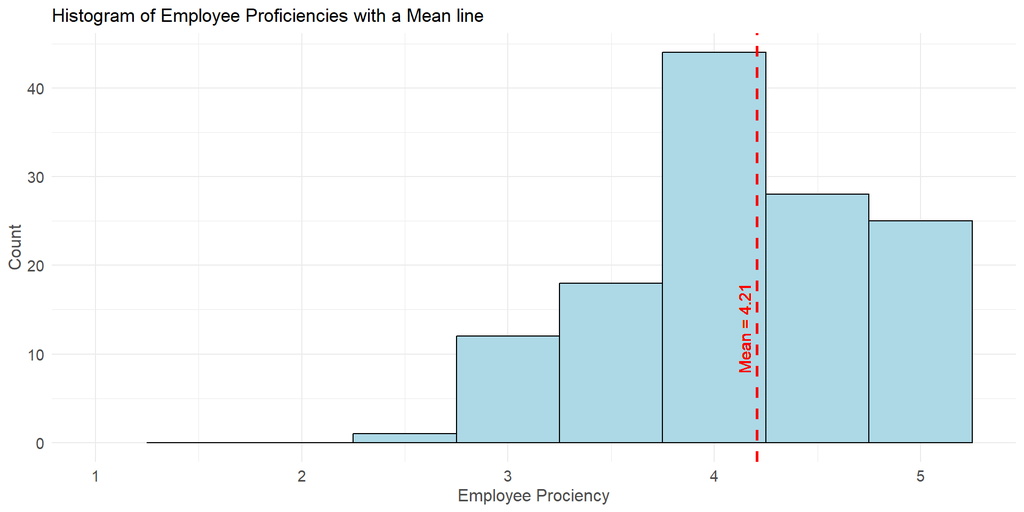

Figure 4: Histogram of Employee Proficiencies (at_emp) with a Mean line

## Reliability/factor analysis

- We already looked at reliability and unidimensionality in the data preparatoin stage.
- The four items are highly representative of the latent construct.
- Therefore, we created a `composite index` and use it

## One-sample t-test

- $H_0: \mu = 4$
- $H_A: \mu \neq 4$

```r
case31 |>
  t.test(at_emp ~ 1, mu = 4, data = _)
```

```
    One Sample t-test

data:  at_emp
t = 3.9063, df = 127, p-value = 0.0001515
alternative hypothesis: true mean is not equal to 4
95 percent confidence interval:
 4.101192 4.308965
sample estimates:
mean of x
 4.205078
```

**Summary insights about R3**

Participants perceived Employee proficiency (*M* = `4.21` out of 5.0) is statistically significantly greater than 4.0 (`"Agree"`) (*p* < .001)

# R4 Overview

R4: Are there any perceived differences on (a) attitude towards employee proficiency, (b) awareness of services, and (c) operational effectiveness between members who live in the area of the firm’s headquarters and members who live elsewhere?

- R4a: Two Samples t-Test
- R4b: Two-way cross-tabs, followed by Chi-square independence test
- R4c: Two tests possible depending on variables to use.
  - 2-groups t-test
  - Ch-square independence test

## R4a Analysis Overview (Two samples t-test)

R4a: Are there any perceived differences on attitude towards employee proficiency between members who live in the area of the firm’s headquarters and members who live elsewhere?

- `Constructs and roles`:
  - Member residence: IV
  - Attitudes toward employee proficiency: DV
- `Operationalization`:
  - q38
  - at_emp
- `Scale`:
  - Nominal scale:
  - interval scale: 1-5 point, Likert-type scale
- `Statistics`:
  - Descriptive statistics, followed by **`independent samples t-test`**

### Descriptives

#### Boxplot

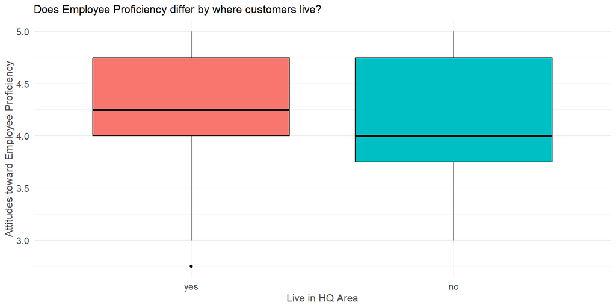

Figure 5: Attitudes toward employee proficiency by residence

#### Barplot

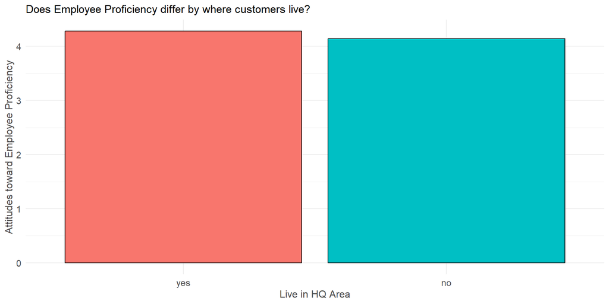

Figure 6: Attitudes toward employee proficiency by residence

### Two independent samples t-test

- Levene’s Test
- Variance test
- Two Samples t-test

```r
library(car)

case31 |>
  mutate(q38 = haven::as_factor(q38)) |>
  leveneTest(at_emp ~ q38, data = _)
```

```
Levene's Test for Homogeneity of Variance (center = median)
       Df F value Pr(>F)
group   1   0.041 0.8399
      126
```

```r
case31 |>
  mutate(q38 = haven::as_factor(q38)) |>
  var.test(at_emp ~ q38, data = _)
```

```
    F test to compare two variances

data:  at_emp by q38
F = 0.89996, num df = 56, denom df = 70, p-value = 0.6864
alternative hypothesis: true ratio of variances is not equal to 1
95 percent confidence interval:
 0.548864 1.496643
sample estimates:
ratio of variances
         0.8999608
```

```r
# t.test: assuming var are equal
case31 |>
  t.test(at_emp ~ q38, data = _, var.equal = TRUE)
```

```
    Two Sample t-test

data:  at_emp by q38
t = 1.2941, df = 126, p-value = 0.198
alternative hypothesis: true difference in means between group 1 and group 2 is not equal to 0
95 percent confidence interval:
 -0.0721542  0.3448253
sample estimates:
mean in group 1 mean in group 2
       4.280702        4.144366
```

#### Summary Table

```r
case31 |>
  mutate(q38 = haven::as_factor(q38)) |>
  tbl_summary(
    include = c(q38, at_emp),
    by = q38,
    type = at_emp ~ "continuous2",
    statistic = list(all_continuous() ~ c("{mean} ({sd})",
                                          "{min}, {max}"))
  ) |>
  add_difference() |>
  add_overall() |>
  add_n() |>
  modify_caption("**Test of Differences in Attitudes toward Employee Proficiency between customers who live in Headquarter area and those who live in non-headquarter area**") |>
  modify_spanning_header(
    c(stat_1, stat_2) ~ "**Live in Headquarter Area?**")
```

Table 1: Do Customers Differ in their Attitudes toward Employee Proficiency depending on where they live?

**Test of Differences in Attitudes toward Employee Proficiency between customers who live in Headquarter area and those who live in non-headquarter area**

| **Characteristic** | **N** | **Overall** N = 128 | **Live in Headquarter Area?** **yes** N = 57 | **Live in Headquarter Area?** **no** N = 71 | **Difference**<sup>1</sup> | **95% CI**<sup>1</sup> | **p-value**<sup>1</sup> |  |  |  |
| --- | --- | --- | --- | --- | --- | --- | --- | --- | --- | --- |
| at_emp | 128 |  |  |  |  |  |  | 0.14 | -0.07, 0.34 | 0.2 |
| Mean (SD) |  | 4.21 (0.59) | 4.28 (0.57) | 4.14 (0.61) |  |  |  |  |  |  |
| Min, Max |  | 2.75, 5.00 | 2.75, 5.00 | 3.00, 5.00 |  |  |  |  |  |  |

Abbreviation: CI = Confidence Interval  
<sup>1</sup> Welch Two Sample t-test

**Summary insights about H4a**

- The group mean value of employee proficiency for `customers who live in HQ` (*M* = 4.28) and `those who live elsewhere` (*M* = 4.14) are not statistically different (*p* > 0.10).
- Thus, we conclude that CU member perception of CU employee proficiency does not differ regardless of whether they live in headquarters area or not.

## R4b Analysis Overview ($\chi^2$ Independence Test)

R4b: Are there any perceived differences on awareness of services between members who live in the area of the firm’s headquarters and members who live elsewhere?

- `Constructs and roles`:
  - Member residence: IV
  - service awareness: DV
- `Operationalization`:
  - q38
  - q13r - q26r
- `Scale`:
  - Nominal scale
  - Ordinal scale
- `Statistics`:
  - Two-way cross-tabs, followed by Chi-square independence test

### q13r (Share account) by q38

- Cleaning
- cross-tab
- Mosaic Plot
- Chi-square test of independence

```r
case31 <- case31 |>
  mutate(q13r = haven::as_factor(q13r),
         q38 = haven::as_factor(q38))
```

```r
table(case31$q13r, case31$q38)
```

```
                          yes no
  Unaware                  34 49
  Aware but Have Not Used  16 16
  Aware and Have Used       7  6
```

```r
# cross-tab: %
table(case31$q13r, case31$q38) |>
  prop.table(margin = 2) * 100
```

```
                                yes        no
  Unaware                 59.649123 69.014085
  Aware but Have Not Used 28.070175 22.535211
  Aware and Have Used     12.280702  8.450704
```

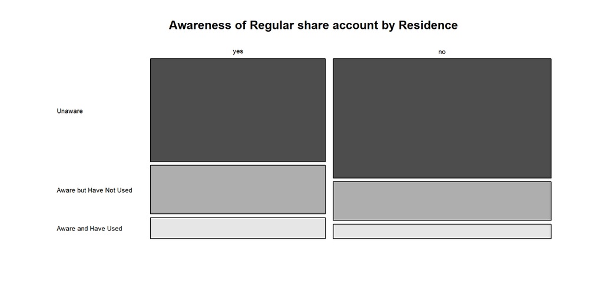

Figure 7: Association of the awareness of regular share account by residence

- $H_0$: Awareness of regular share account is `independent` of members’ residence
- $H_A$: Awareness of regular share account is `dependent` on members’ residence

```r
table(case31$q13r, case31$q38) |>
  chisq.test()
```

```
    Pearson's Chi-squared test

data:  table(case31$q13r, case31$q38)
X-squared = 1.2717, df = 2, p-value = 0.5295
```

**Note**: The various steps in in slide can be more effectively followed in a regular report. In a presentation like this, a simpler but more visually effective summary table, like the publication-ready table, using `gt-summary` package. Refer to Table 2.

**Insights**

- Members’ awareness of regular share account is not associated with the place of members’ residence.
- Paraphrasing, members’ awareness of regular share account is independent of where they live.

### q14r (Special subaccounts) by q38

- Cleaning
- Cross-tab
- Mosaic Plot
- Chi-square test of independence

```r
case31 <- case31 |>
  mutate(q14r = haven::as_factor(q14r))
```

```r
# cross-tabulation: count

table(case31$q14r, case31$q38)
```

```
                          yes no
  Unaware                  22 24
  Aware but Have Not Used  31 39
  Aware and Have Used       4  8
```

```r
# cross-tab: %
table(case31$q14r, case31$q38) |>
  prop.table(margin = 2) * 100
```

```
                                yes        no
  Unaware                 38.596491 33.802817
  Aware but Have Not Used 54.385965 54.929577
  Aware and Have Used      7.017544 11.267606
```

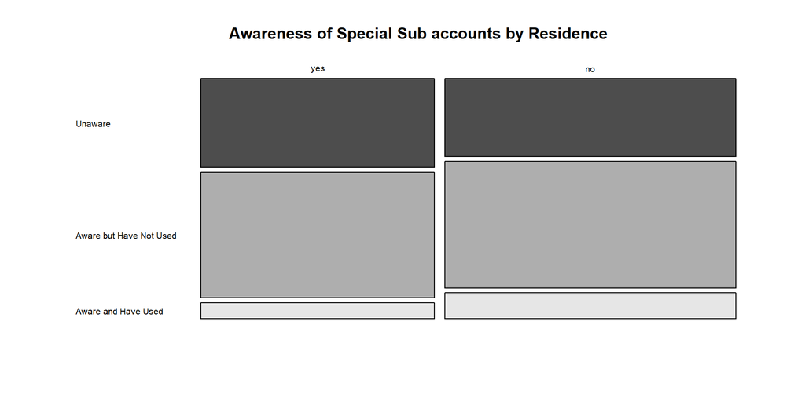

```r
table(case31$q14r, case31$q38) |>
  chisq.test()
```

```
    Pearson's Chi-squared test

data:  table(case31$q14r, case31$q38)
X-squared = 0.81305, df = 2, p-value = 0.666
```

### q15r by q38 with gt_summary table

- q15r (Christmas club account)

```r
case31 <- case31 |>
  mutate(q15r = haven::as_factor(q15r))

case31 |>
  tbl_summary(
    include = c(q15r, q38),
    by = q38
  ) |>
  add_p() |>
  modify_spanning_header(all_stat_cols() ~ "**Live in HQ Area?**") |>
  add_n() |>
  italicize_labels() |>
  #show_header_names()
  modify_header(label ~ "**Awareness**") |>
  as_gt() |>
  tab_header(
    title = md("**Chi-Square Test of Independece**"),
    subtitle = md("*Christmas Club Account Awareness by Where Customers Live*")
  )
```

Table 2: Christmas Club Account Awareness by Location of Residence

**Chi-Square Test of Independece**

*Christmas Club Account Awareness by Where Customers Live*

| **Awareness** | **N** | **Live in HQ Area?** **yes** N = 57<sup>1</sup> | **Live in HQ Area?** **no** N = 71<sup>1</sup> | **p-value**<sup>2</sup> |  |
| --- | --- | --- | --- | --- | --- |
| Christmas club account | 128 |  |  |  | 0.9 |
| Unaware |  | 17 (30%) | 25 (35%) |  |  |
| Aware but Have Not Used |  | 35 (61%) | 40 (56%) |  |  |
| Aware and Have Used |  | 5 (8.8%) | 6 (8.5%) |  |  |

<sup>1</sup> n (%)  
<sup>2</sup> Fisher’s exact test

### Further cleaning

```r
case31_clean <- case31 |>
  mutate(q13r = haven::as_factor(q13r),
         q14r = haven::as_factor(q14r),
         q15r = haven::as_factor(q15r),
         q16r = haven::as_factor(q16r),
         q17r = haven::as_factor(q17r),
         q18r = haven::as_factor(q18r),
         q19r = haven::as_factor(q19r),
         q20r = haven::as_factor(q20r),
         q21r = haven::as_factor(q21r),
         q22r = haven::as_factor(q22r),
         q23r = haven::as_factor(q23r),
         q24r = haven::as_factor(q24r),
         q25r = haven::as_factor(q25r),
         q26r = haven::as_factor(q26r)
         )
```

### Creating a function for chi-square independence test

```r
chisq_ind_test <- function(data, var) {

  library(dplyr)
  library(rlang)
  library(glue)

  var <- enquo(var)  # Capture the column as a quosure

  # Remove NA's
  data <- data |>
    filter(!is.na(!!var), !is.na(q38))

  # Remove unused levels to avoid errors in chi-square test
  data <- data |>
  mutate(!!var := droplevels(!!var)) # dynamic column name

  # Cross-tab
  tab <- table(pull(data, !!var), data$q38)

  # Cross-tab: %
  prop_tab <- prop.table(tab, margin = 2) * 100

  # Mosaic Plot
  tab_c <- table(data$q38, pull(data, !!var))

  mosaicplot(
    tab_c,
    main = glue::glue("Awareness of {quo_name(var)} by Residence"),
    color = TRUE, las = 1
  )

  # Chi-square test of independence
  chi_sq_result <- chisq.test(tab)

  # Return results as a list
  list(
    crosstab = tab,
    proportions = prop_tab,
    chi_square = chi_sq_result
  )
}
```

### Testing all

```r
awareness <- vars(q13r, q14r, q15r, q16r, q17r, q18r, q19r, q20r, q21r, q22r, q23r, q24r, q25r, q26r) # Quote the variables

awareness |>
  map(~ chisq_ind_test(case31_clean, !!.x))
```

#### testing for q26r by q38

```r
case31_clean |>
  chisq_ind_test(q26r)
```

```
$crosstab

                          yes no
  Aware but Have Not Used  37 43
  Aware and Have Used      20 28

$proportions

                               yes       no
  Aware but Have Not Used 64.91228 60.56338
  Aware and Have Used     35.08772 39.43662

$chi_square

    Pearson's Chi-squared test with Yates' continuity correction

data:  tab
X-squared = 0.10332, df = 1, p-value = 0.7479
```

[figure not shown]

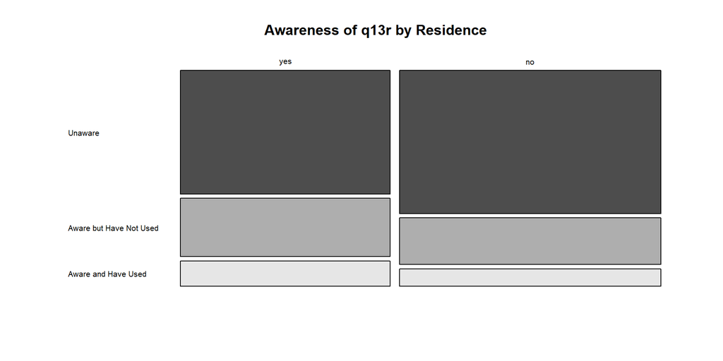

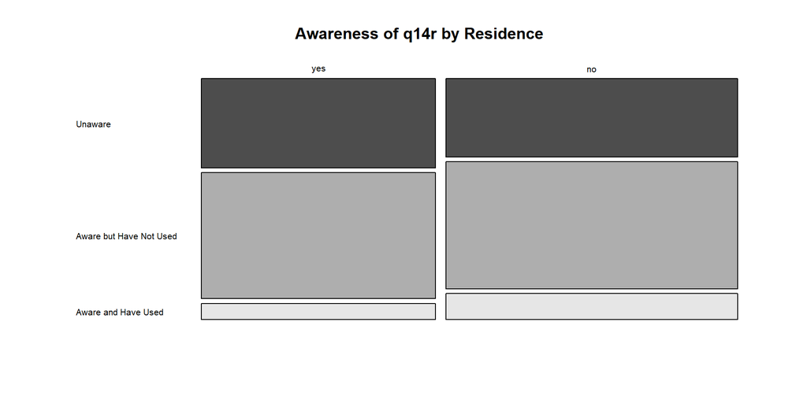

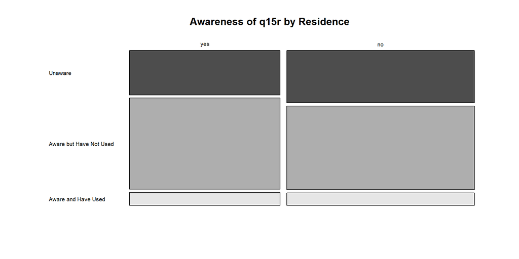

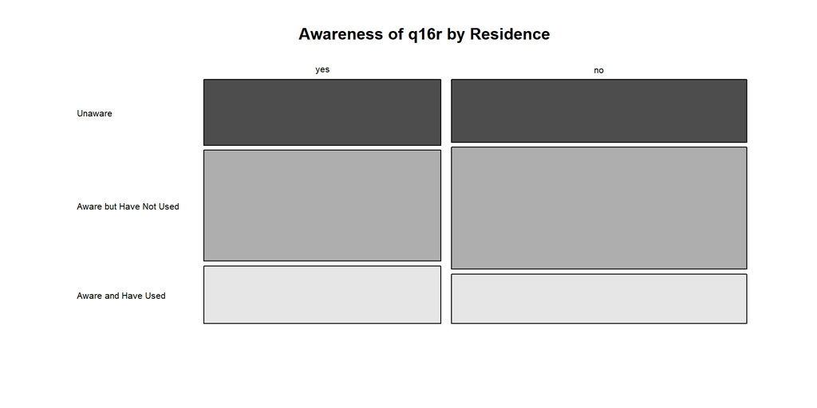

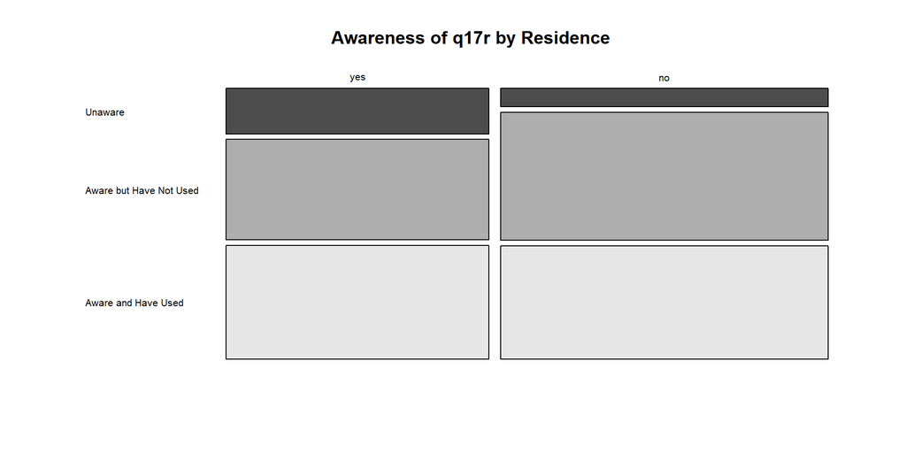

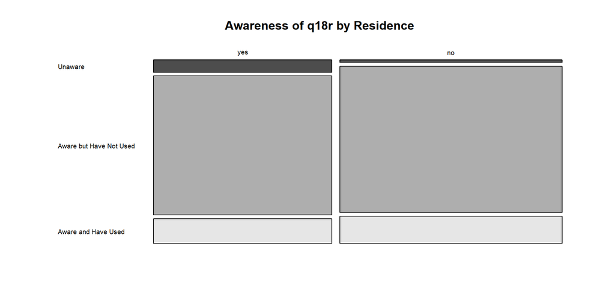

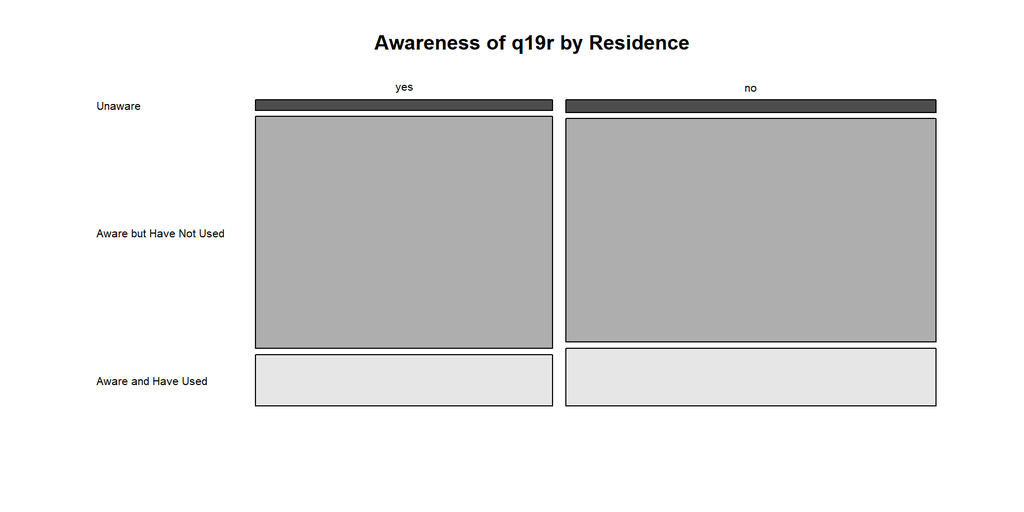

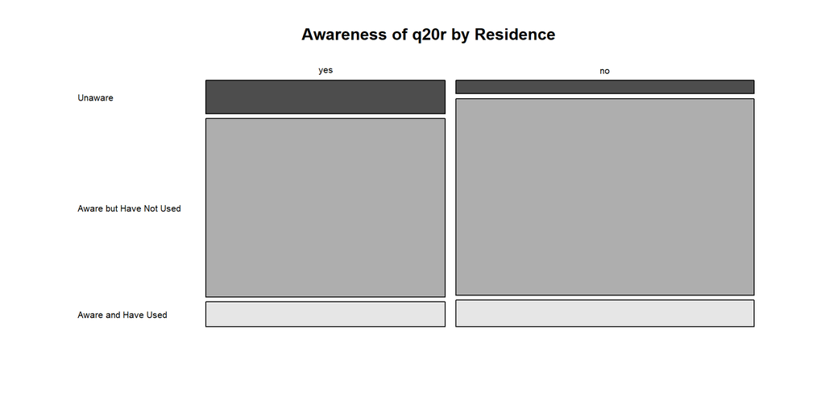

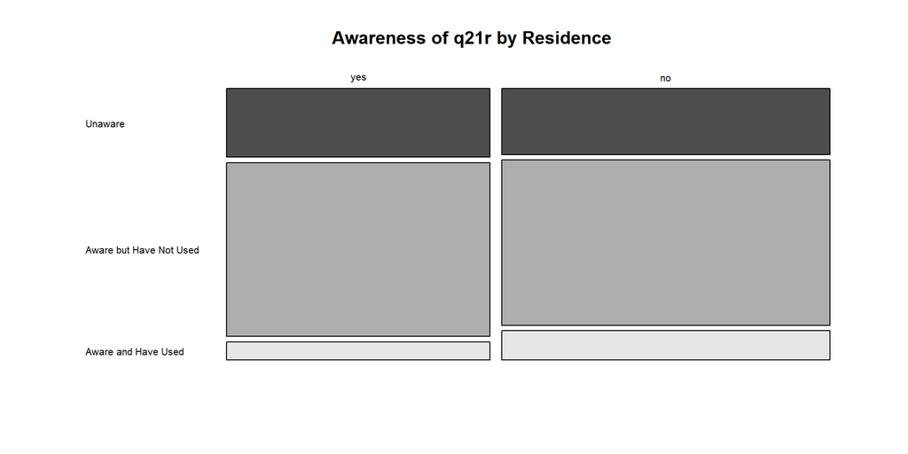

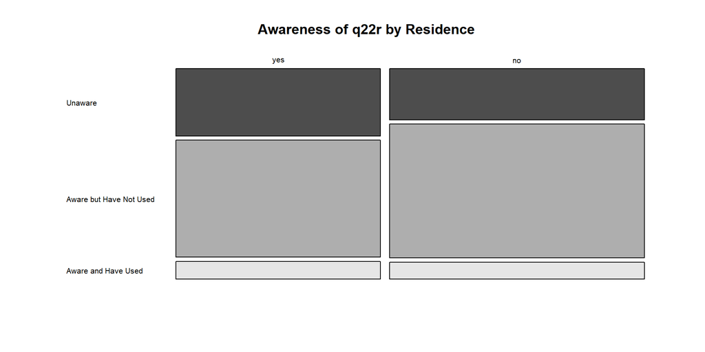

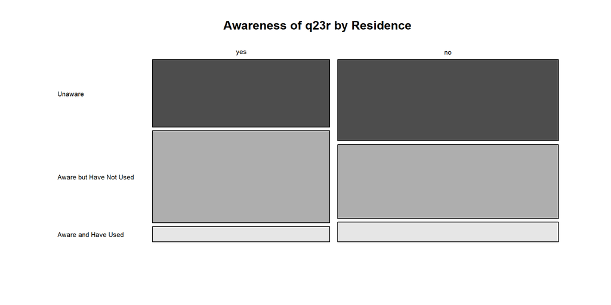

[3 more figures not shown]

[output not shown]

[output cut: 276 more lines]

[output not shown]

## R4c Analysis Overview

- R4c: Are there any perceived differences on operational effectiveness between members who live in the area of the firm’s headquarters and members who live elsewhere?
- `Constructs and roles`:
  - Member residence: IV
  - operatoinal effectiveness: DV
- `Operationalization`:
  - q38
  - q9r, q10r,
  - q11-q12r,
  - q31-q34,
  - q37r
- `Scale`:
  - Nominal scale
  - interval scales
  - Nominal
  - interval
  - interval
- `Statistics`:
  - Descriptive statistics, followed by
    - 2-groups t-test
    - Ch-square independence test
    - 2-groups t-test
    - 2-groups t-test

# R5 ($\chi^2$ Goodness of Fit)

R5: How well are the members aware of the services offered by the credit union?

- `Constructs and roles`:
  - Awareness of services:
- `Operationalization`:
  - q13r-q26r
- `Scale`:
  - Ordinal scale:
- `Statistics`:
  - Chi-square goodness-of-fit test

## q13r

### Summary table

```r
case31_clean |>
  tbl_summary(
    include = q13r,
    type = all_categorical() ~ "categorical"
  ) |>
  italicize_labels() |>
  #show_header_names()
  modify_header(label ~ "**Awareness**") |>
  modify_caption("**Chi-Square Goodness of Fit Test**:<br>*Regular Share Account Awareness*")
```

Table 3: Regular Share Account Awareness Frequency

**Chi-Square Goodness of Fit Test**: *Regular Share Account Awareness*

| **Awareness** | **N = 128**<sup>1</sup> |
| --- | --- |
| Regular share account |  |
| Unaware | 83 (65%) |
| Aware but Have Not Used | 32 (25%) |
| Aware and Have Used | 13 (10%) |

<sup>1</sup> n (%)

### Barplot

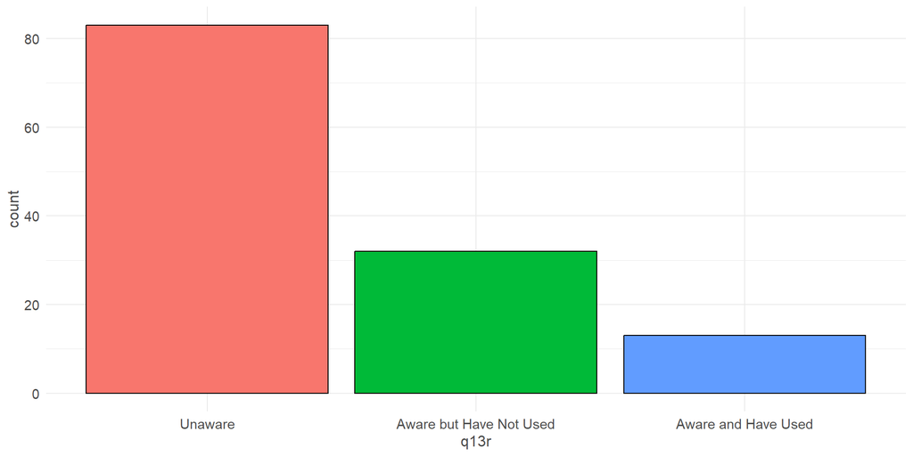

```r
case31_clean |>
  ggplot(aes(q13r, fill = q13r)) +
  geom_bar() +
  theme(legend.position = "none")
```

### Chi-square Goodness-of-fit test

```r
expected = c(1/3, 1/3, 1/3)
table(case31_clean$q13r) |>
  chisq.test(p = expected)
```

```
    Chi-squared test for given probabilities

data:  table(case31_clean$q13r)
X-squared = 61.422, df = 2, p-value = 4.596e-14
```

**Insights**

- There is statistically significant evidence that the observed data doesn’t follow from the theoretical distribution
- the level of members’ awareness of regular share account is different across the three levels with “unawareness being highest

## More efficient testing with a function

```r
# data

awareness_long <- case31_clean |>
  select(q13r:q26r) |>
  pivot_longer(cols = everything(),
               names_to = "services",
               values_to = "aware_level")
awareness_long
```

```
# A tibble: 1,792 × 2
   services aware_level
   <chr>    <fct>
 1 q13r     Aware and Have Used
 2 q14r     Aware but Have Not Used
 3 q15r     Aware but Have Not Used
 4 q16r     Aware but Have Not Used
 5 q17r     Aware but Have Not Used
 6 q18r     Aware but Have Not Used
 7 q19r     Aware and Have Used
 8 q20r     Aware and Have Used
 9 q21r     Aware but Have Not Used
10 q22r     Aware but Have Not Used
# ℹ 1,782 more rows
```

```r
# Expected proportions (e.g., equal distribution across levels)
exp_p <- c(`Unaware` = 1/3,
           `Aware but Have Not Used` = 1/3,
           `Aware and Have Used` = 1/3)

# Perform chi-square goodness of fit for each product
awareness_long |>
  group_by(services) |>
  count(aware_level) |>
  complete(aware_level = names(exp_p), fill = list(n = 0)) |> # tidyr
  group_by(services) |>
  summarise(
    chisq_test = list(chisq.test(
      x = n,
      p = exp_p[levels(factor(aware_level))]
  ))
  ) |>
  mutate(tidy_results = map(chisq_test, broom::tidy)) |>
  unnest(tidy_results)
```

```
# A tibble: 14 × 6
   services chisq_test statistic  p.value parameter method
   <chr>    <list>         <dbl>    <dbl>     <dbl> <chr>
 1 q13r     <htest>         61.4 4.60e-14         2 Chi-squared test for given …
 2 q14r     <htest>         39.8 2.26e- 9         2 Chi-squared test for given …
 3 q15r     <htest>         48.0 3.75e-11         2 Chi-squared test for given …
 4 q16r     <htest>         16.4 2.72e- 4         2 Chi-squared test for given …
 5 q17r     <htest>         26.9 1.43e- 6         2 Chi-squared test for given …
 6 q18r     <htest>        135.  6.07e-30         2 Chi-squared test for given …
 7 q19r     <htest>        116.  7.16e-26         2 Chi-squared test for given …
 8 q20r     <htest>        124.  1.30e-27         2 Chi-squared test for given …
 9 q21r     <htest>         62.4 2.88e-14         2 Chi-squared test for given …
10 q22r     <htest>         56.9 4.36e-13         2 Chi-squared test for given …
11 q23r     <htest>         31.2 1.65e- 7         2 Chi-squared test for given …
12 q24r     <htest>         59.8 1.02e-13         2 Chi-squared test for given …
13 q25r     <htest>         64.6 9.56e-15         2 Chi-squared test for given …
14 q26r     <htest>         76   3.14e-17         2 Chi-squared test for given …
```

**Insights about R5**

- Series of Chi-square goodness-of-fit statistics show and for all services, frequency distributions of awareness levels are significantly different from each other and the pattern of differences are quite similar with unawareness being largest across all types of financial services.
- The company should increase the awareness.

# R6 Overview ($\chi^2$ & t-test)

R6: What are the members’ attitudes and beliefs about how effectively the credit union is operated?

- `Constructs and roles`:
  - Attitude toward operational effectiveness
- `Operationalization`:
  - Q9r–Q10r
  - Q11–Q12rc,
  - Q31 – Q34
  - Q37r
- `Scale`:
  - ordinal/internal scale
  - nominal scale
  - Interval
  - Interval
- `Statistics`:
  - DS / Chi-square goodness-of-fit test
  - DS / Chi-square goodness-of-fit test
  - DS / One group t-test
  - DS / One group t-test

# H1 Overview - One-way ANOVA

H1: Members’ awareness of the regular share accounts will influence their opinions on the adequacy of financial services in meeting members’ needs.

- `Constructs and roles`:
  - Members’ awareness of the regular share account (IV)
  - Adequacy of financial services in meeting member needs (DV)
- `Operationalization`:
  - q13r
  - q33
- `Scale`:
  - Ordinal scale
  - Interval
- `Statistics`:
  - DS / One-way ANOVA

## Visualization

### Frequency by groups

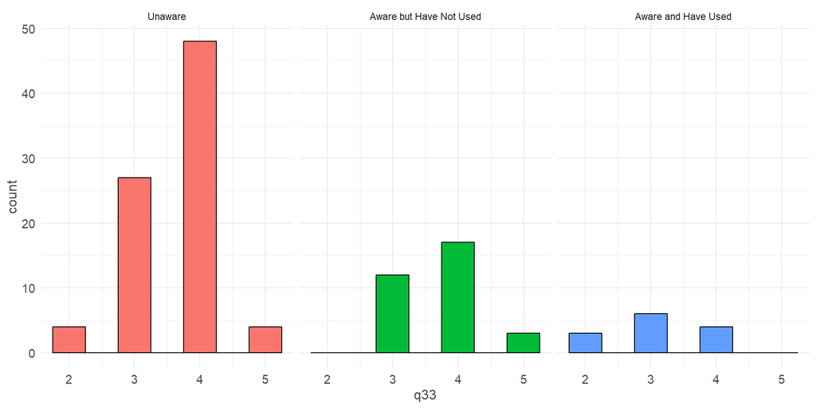

Figure 8: Frequency Distribution of Adequacy of Financial Services in Meeting Members’ Needs (q33) by Their Awareness of Regular Share Accounts (q13r)

### Mean value by groups

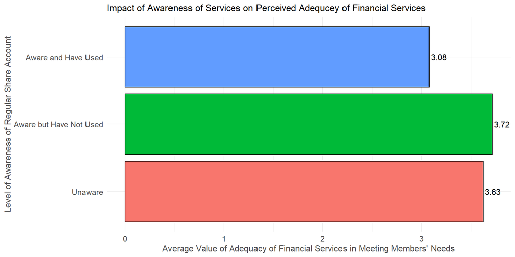

Figure 9: Mean VAlue of Adequacy of Financial Services in Meeting Members’ Needs (q33) by Their Awareness of Regular Share Accounts (q13r)

## ANOVA Test Procedure

### 1. Check normality assumption

- The dependent variable should be approximately normally distributed within each group.
- $H_0:$ The data are normally distributed
- $H_1:$ The data are NOT normally distributed

#### Overall test for q33

```r
# Shapiro-Wilk normality test

case31_clean |>
  pull(q33) |>
  shapiro.test()
```

```
    Shapiro-Wilk normality test

data:  pull(case31_clean, q33)
W = 0.80776, p-value = 1.176e-11
```

#### Test by awareness group on q33

```r
case31_clean |>
  group_by(q13r) |>
  summarise(p_value = shapiro.test(pull(cur_data(), q33))$p.value)
```

```
# A tibble: 3 × 2
  q13r                          p_value
  <fct>                           <dbl>
1 Unaware                 0.00000000133
2 Aware but Have Not Used 0.0000121
3 Aware and Have Used     0.0136
```

#### Test of Normality on Residuals

```r
h1_aov_model <- case31_clean |>
  aov(q33 ~ q13r, data = _)

residuals(h1_aov_model) |>
  shapiro.test()
```

```
    Shapiro-Wilk normality test

data:  residuals(h1_aov_model)
W = 0.87843, p-value = 7.927e-09
```

### 2. Homogeneity of variance

```r
library(car)
case31_clean |>
  leveneTest(q33 ~ q15r, data = _)
```

```
Levene's Test for Homogeneity of Variance (center = median)
       Df F value Pr(>F)
group   2  1.0002 0.3707
      125
```

### 3. ANOVA Test

- $H_0:$ All group means are equal ($\mu_1 = \mu_2 = \mu_3 = ... = \mu_k$)
- $H_1:$ At least one pair of group means is different

#### Under homoskedasticity

```r
case31_clean |>
  aov(q33 ~ q13r, data = _) |>
  summary()
```

```
             Df Sum Sq Mean Sq F value Pr(>F)
q13r          2   4.06  2.0307   4.631 0.0115 *
Residuals   125  54.81  0.4385
---
Signif. codes:  0 '***' 0.001 '**' 0.01 '*' 0.05 '.' 0.1 ' ' 1
```

#### Since residuals are non-normal

- Kruskal-Wallis Test
  - non-parametric
  - compares the medians of three or more independent groups to determine if they differ significantly.

```r
case31_clean |>
  kruskal.test(q33 ~ q13r, data = _)
```

```
    Kruskal-Wallis rank sum test

data:  q33 by q13r
Kruskal-Wallis chi-squared = 7.1098, df = 2, p-value = 0.02858
```

### 4. Summary Table

```r
anova_model <- case31_clean |>
  aov(q33 ~ q13r, data = _)

anova_summary <- summary(anova_model)

anova_pvalue <- anova_summary[[1]][["Pr(>F)"]][1]

case31_clean |>
  mutate(q33 = as.numeric(q33)) |>
  tbl_summary(
    include = c(q13r, q33),
    by = q13r,
    type = q33 ~ "continuous2",
    statistic = list(all_continuous() ~ c("{mean} ({sd})",
                                          "{min}, {max}")),
    label = q33 ~ "Adequacy of Financial Services"
  ) |>
  modify_spanning_header(
    all_stat_cols() ~ "**Regular Share Account Awareness Levels**") |>
  add_overall() |>
  modify_caption("**Test of Differences in Perceived Adequacy of Financial Services in Meeting Memberss Needs:**<br>_Diffential Effect by Awareness of Regular Share Account (q13r)_") |>
  italicize_labels() |>
  modify_footnote(
    c(stat_1, stat_2, stat_3) ~ glue::glue("One-way ANOVA with equal variance assummed p-value: {format.pval(anova_pvalue, digits = 3)}")) |>
  #show_header_names()
  modify_header(label ~ "**Variable**")
```

Table 4: Does Awareness of Regular Share Account Affects Members’ Perceived Adequacy of Financial Services in Meeting their Needs?

**Test of Differences in Perceived Adequacy of Financial Services in Meeting Memberss Needs:** *Diffential Effect by Awareness of Regular Share Account (q13r)*

| **Variable** | **Overall** N = 128 | **Regular Share Account Awareness Levels** **Unaware** N = 83<sup>1</sup> | **Regular Share Account Awareness Levels** **Aware but Have Not Used** N = 32<sup>1</sup> | **Regular Share Account Awareness Levels** **Aware and Have Used** N = 13<sup>1</sup> |
| --- | --- | --- | --- | --- |
| Adequacy of Financial Services |  |  |  |  |
| Mean (SD) | 3.59 (0.68) | 3.63 (0.66) | 3.72 (0.63) | 3.08 (0.76) |
| Min, Max | 2.00, 5.00 | 2.00, 5.00 | 3.00, 5.00 | 2.00, 4.00 |

<sup>1</sup> One-way ANOVA with equal variance assummed p-value: 0.0115

**Note**: ANOVA with more than 2 levels cannot be computed in `gt_summary()`(Sjoberg et al. 2021). Thus, p-value should be obtained separately from aov and added to the table as a footnote.

### 5. Post-hoc Analysis if not all group means are the same

#### When ANOVA is significant

```r
case31_clean |>
  aov(q33 ~ q13r, data = _) |>
  TukeyHSD()
```

```
  Tukey multiple comparisons of means
    95% family-wise confidence level

Fit: aov(formula = q33 ~ q13r, data = case31_clean)

$q13r
                                                   diff        lwr         upr
Aware but Have Not Used-Unaware              0.09224398 -0.2345927  0.41908065
Aware and Have Used-Unaware                 -0.54958295 -1.0180950 -0.08107087
Aware and Have Used-Aware but Have Not Used -0.64182692 -1.1584282 -0.12522563
                                                p adj
Aware but Have Not Used-Unaware             0.7816413
Aware and Have Used-Unaware                 0.0170339
Aware and Have Used-Aware but Have Not Used 0.0106252
```

#### When Kruskal-Wallis is significant

```r
library(dunn.test)

# Post-hoc pairwise comparisons
dunn.test(as.numeric(case31_clean$q33), case31_clean$q13r, method = "bonferroni")
```

```
  Kruskal-Wallis rank sum test

data: x and group
Kruskal-Wallis chi-squared = 7.1098, df = 2, p-value = 0.03

                           Comparison of x by group
                                 (Bonferroni)
Col Mean-|
Row Mean |   Aware an   Aware bu
---------+----------------------
Aware bu |  -2.534359
         |    0.0169*
 Unaware |  -2.501555   0.419916
         |    0.0185*     1.0000

alpha = 0.05
Reject Ho if p <= alpha/2
```

**Insights about H1**

# H2: Overview - Paired Samples t-Test

H2: Members will not be different in their opinion on CU’s loan rate (Q8r) and the degree to which they agree that CU’s loan rate is lower than competitors (Q30).

# H3a: Overview - Two-way ANOVA

H3a: There will be interaction effect between the current loan use and location of residence on adequacy of current financial services such that in headquarter area, members who have a loan will agree, more than those who don’t have, that financial services meet the members’ needs, while in outside headquarter area, loan status doesn’t influence adequacy of financial services in meeting member needs.

# H3b: Overview - Two-way ANCOVA

H3b: Test H2a controlling for the impact of attitudes toward employee proficiency.

# H4: Overview - MANOVA

H4: Compared with the members who have a loan, those members who don’t have a loan currently with the Credit Union will feel that that CU charges them with higher rates, and that they will agree less with the statement that CU’s loan rates are lower than those offered by other institutions.

# H5: Overview - Multiple Regression

H5a: Member belief about CU keeps personal `financial information confidential` will positively influence the overall attitude toward credit union’s operational efficiency.

H5b: `Loan application processing promptness` will positively influence the overall attitude toward credit union’s operational efficiency.

H5c: `Member satisfaction with level of financial services in meeting needs` will positively influence the overall attitude toward credit union’s operational efficiency.

H5d: `Loan application simplicity and easiness` will positively influence the overall attitude toward credit union’s operational efficiency.

- `Constructs and roles`:
  1. Overall managerial and operational efficiency (DV)
  2. Confidentiality of personal financial information (IV)
  3. Loan application processing promptness (IV)
  4. Adequacy of financial services in meeting needs (IV)
  5. Simplicity and easiness of loan application (IV)
- `Operationalization`:
  1. q37r
  2. q31
  3. q32
  4. q33
  5. q34
- `Scale`:
  - all of them are interval
- `Statistics`:
  - separate visualization, followed by `multiple regression`

## Checking Assumptions of Multiple Regression

### 1. Linearity Check

- q31 vs. q37r
- q32 vs. q37r
- q33 vs. q37r
- q34 vs. q37r
- Partial residual plots

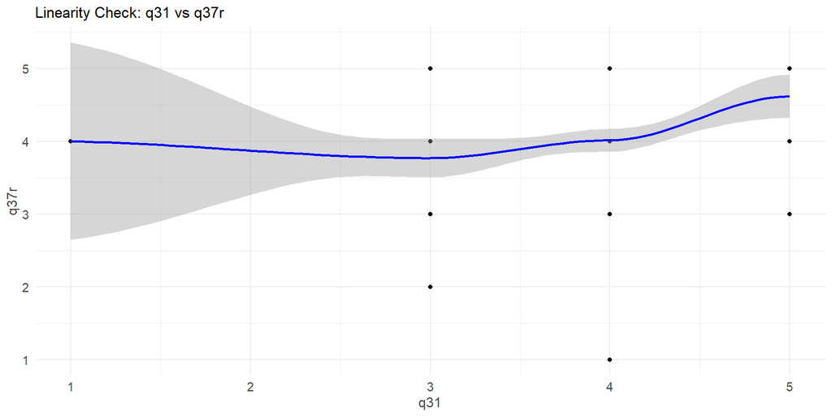

```r
# Scatterplot for each predictor against the outcome
ggplot(case31_clean, aes(x = q31, y = q37r)) +
  geom_point() +
  geom_smooth(col = "blue") +
  labs(title = "Linearity Check: q31 vs q37r")
```

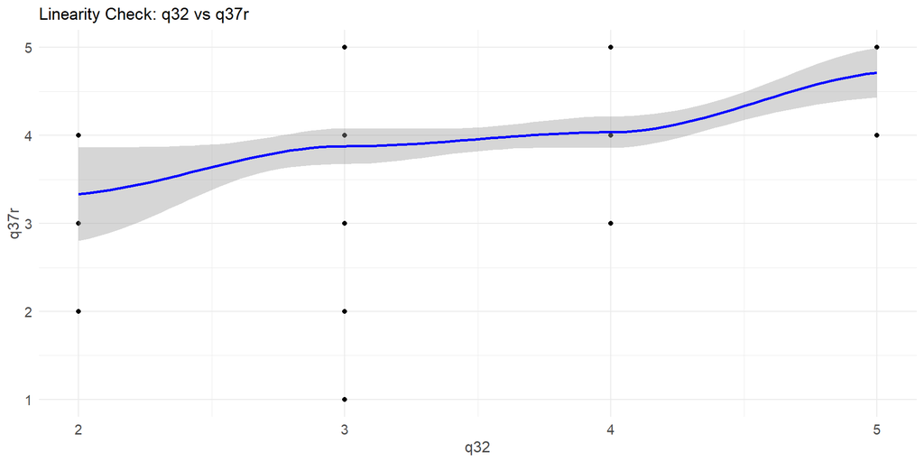

```r
# Scatterplot for each predictor against the outcome
ggplot(case31_clean, aes(x = q32, y = q37r)) +
  geom_point() +
  geom_smooth(col = "blue") +
  labs(title = "Linearity Check: q32 vs q37r")
```

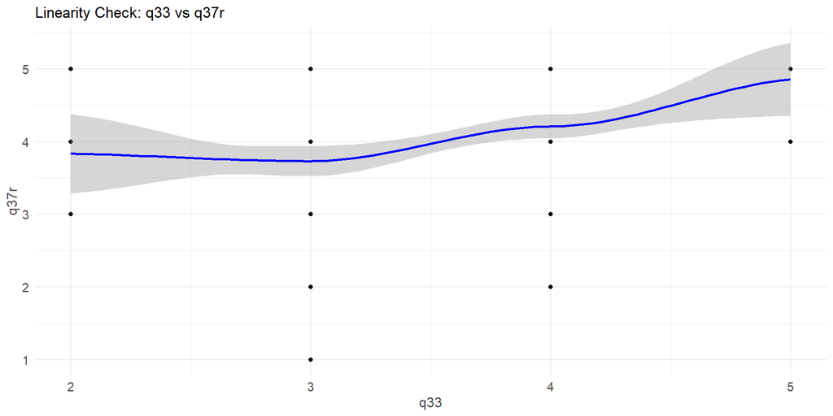

```r
# Scatterplot for each predictor against the outcome
ggplot(case31_clean, aes(x = q33, y = q37r)) +
  geom_point() +
  geom_smooth(col = "blue") +
  labs(title = "Linearity Check: q33 vs q37r")
```

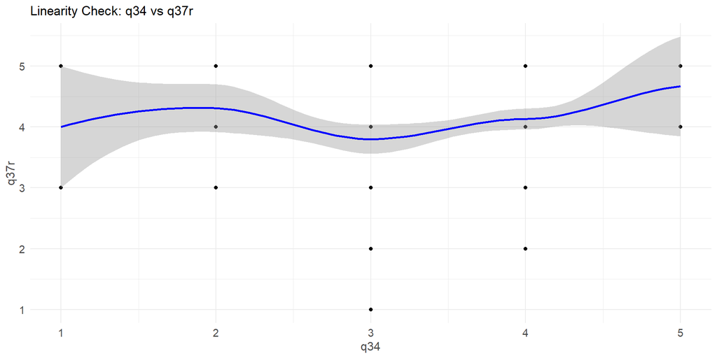

```r
# Scatterplot for each predictor against the outcome
ggplot(case31_clean, aes(x = q34, y = q37r)) +
  geom_point() +
  geom_smooth(col = "blue") +
  labs(title = "Linearity Check: q34 vs q37r")
```

- visualize the relationship between a predictor and the response variable, accounting for the effects of other predictors in the model.
- If the relationship between the predictor and the response is linear, the points in the plot should roughly follow a straight line.

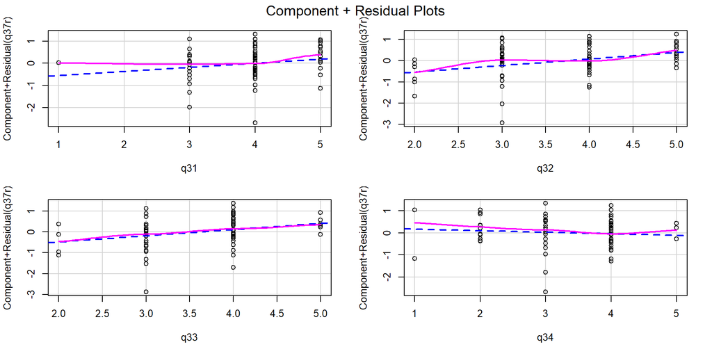

```r
library(car)
lm_model <- case31_clean |>
  filter(!is.na(q37r)) |>
  lm(q37r ~ q31 + q32 + q33 + q34, data = _)
crPlots(lm_model)
```

### 2. Independence Check

- $H_0:$ There is no first-order autocorrelation in the residuals (errors are independent).
- $H_1:$ There is evidence of positive or negative autocorrelation.
- Test statistics (d)
  - $d \approx 2$: No autocorrelation
  - $d < 2$: Positive autocorrelation
  - $d > 2$: Negative autocorrelation

```r
library(lmtest)
dwtest(lm_model)  # Durbin-Watson test for autocorrelation
```

```
    Durbin-Watson test

data:  lm_model
DW = 2.2276, p-value = 0.8995
alternative hypothesis: true autocorrelation is greater than 0
```

### 3. Homoscedasticity Check

- Residuals vs. Fitted Plot
- bp test

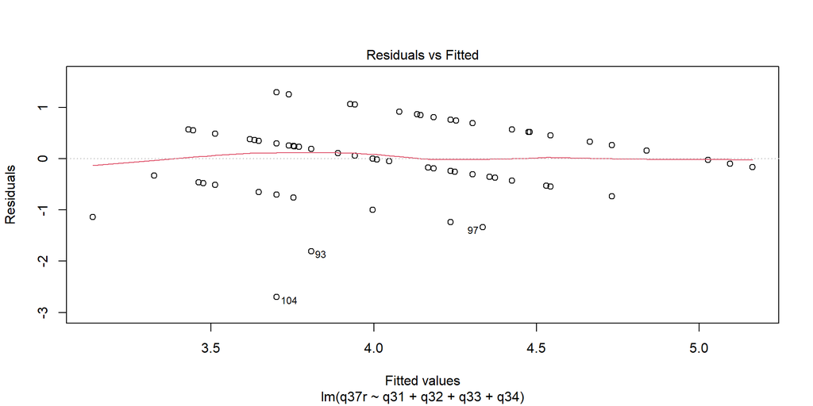

```r
plot(lm_model, which = 1)  # Built-in residuals vs. fitted plot
```

- $H_0:$ The errors have constant variance (homoscedasticity).
- $H_1:$ The errors exhibit heteroscedasticity (i.e., non-constant variance).

```r
library(lmtest)
bptest(lm_model)  # Breusch-Pagan test for heteroscedasticity
```

```
    studentized Breusch-Pagan test

data:  lm_model
BP = 4.5897, df = 4, p-value = 0.332
```

### 4. Normality of Residuals

- Histogram of residuals
- Q-Q Plot
- Test of normality

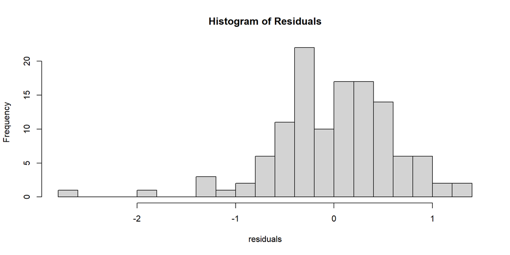

```r
residuals <- residuals(lm_model)
hist(residuals, breaks = 20, main = "Histogram of Residuals")
```

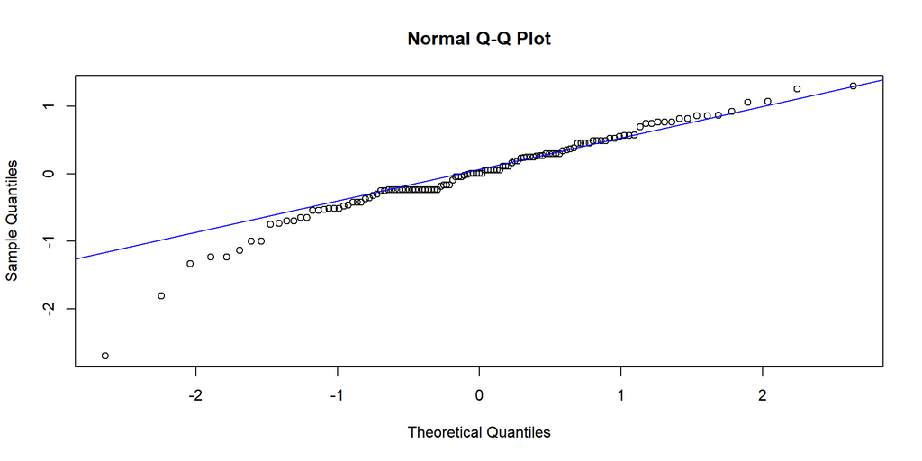

```r
qqnorm(residuals)
qqline(residuals, col = "blue")
```

- $H_0:$ The data is normally distributed
- $H_1:$ The data is not normally distributed.

```r
shapiro.test(residuals)  # Shapiro-Wilk test
```

```
    Shapiro-Wilk normality test

data:  residuals
W = 0.95406, p-value = 0.0004082
```

### 5. Multicollinearity Check

- VIF > 5: Possible multicollinearity.
- VIF > 10: Strong multicollinearity, consider dropping or combining predictors.

```r
library(car)
vif(lm_model)  # VIF values
```

```
     q31      q32      q33      q34
1.148240 1.396267 1.065648 1.214352
```

### 6. Outliers and Influential Observations

- Cook’s Distance
- Leverage and DFBETAS

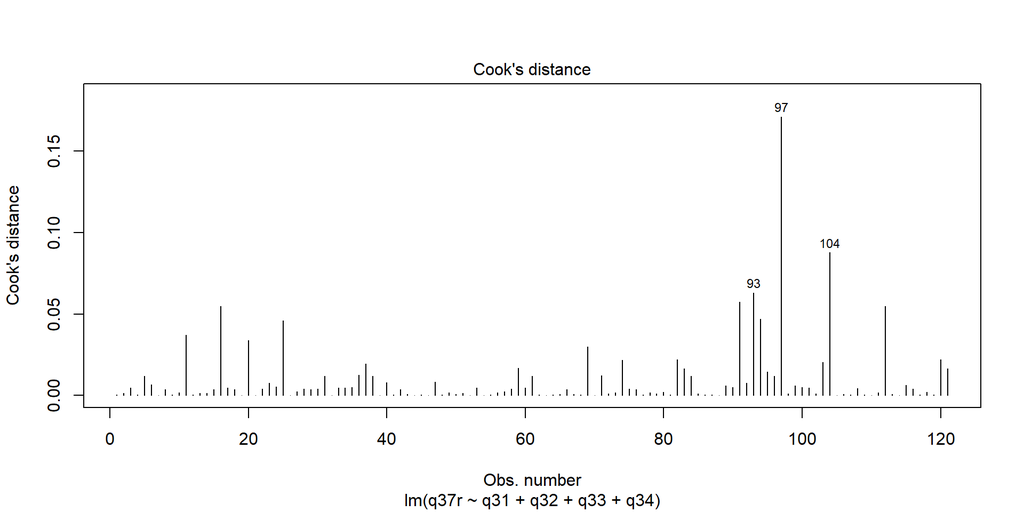

```r
plot(lm_model, which = 4)  # Built-in Cook's distance plot
```

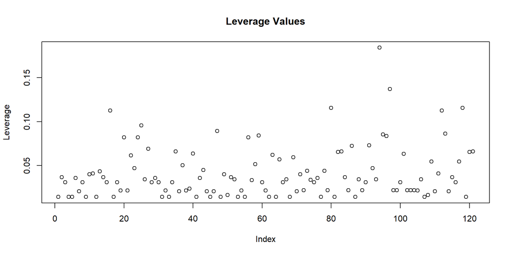

```r
# Leverage Plot
hatvalues <- hatvalues(lm_model)
plot(hatvalues, main = "Leverage Values", ylab = "Leverage")
```

```r
# DFBETAS
dfbetas <- dfbeta(lm_model)
head(dfbetas)  # Shows influence of each observation
```

```
   (Intercept)           q31           q32          q33          q34
1  0.009403795 -0.0001015945  0.0001734095 -0.001583996 -0.001698192
2  0.018803471 -0.0047139437  0.0022874976 -0.002830564  0.001025494
3 -0.064176774  0.0078605827  0.0010204438  0.004270726  0.002766490
4  0.009403795 -0.0001015945  0.0001734095 -0.001583996 -0.001698192
5  0.049299034 -0.0005326053  0.0009090924 -0.008304040 -0.008902708
6 -0.059692744  0.0126198994 -0.0041741897  0.002834174  0.005853614
```

### 7. Cross-validation

#### Define control for cross-validation

```r
library(caret)
set.seed(123)

train_control <- trainControl(method = "cv", number = 10)

case31_clean <- case31_clean |>
  filter(!is.na(q37r)) |>
  mutate(q37r = as.numeric(q37r))
```

#### Train the model

```r
cv_model <- train(
  q37r ~ q31 + q32 + q33 + q34,
  data = case31_clean,
  method = "lm",
  trControl = train_control)

cv_model  # Check cross-validation results
```

```
Linear Regression

121 samples
  4 predictor

No pre-processing
Resampling: Cross-Validated (10 fold)
Summary of sample sizes: 108, 109, 109, 109, 109, 109, ...
Resampling results:

  RMSE       Rsquared   MAE
  0.6080421  0.3155103  0.483605

Tuning parameter 'intercept' was held constant at a value of TRUE
```

```r
cv_model$resample
```

```
        RMSE   Rsquared       MAE Resample
1  0.3845295 0.61980439 0.3360649   Fold01
2  1.0946785 0.10531564 0.8239592   Fold02
3  0.4962708 0.03110875 0.4335815   Fold03
4  0.6498566 0.02311003 0.4974842   Fold04
5  0.4871213 0.46218519 0.3913416   Fold05
6  0.6067156 0.26438525 0.4945987   Fold06
7  0.5833334 0.60333089 0.4652271   Fold07
8  0.5420575 0.54103610 0.4160615   Fold08
9  0.4332916 0.44055235 0.3583005   Fold09
10 0.8025663 0.06427416 0.6194310   Fold10
```

### Model Parameters

- Final Model Parameters from CV
- Multiple Regression & Results

```r
summary(cv_model) # summary function returns final model fit based on entire data
```

```
Call:
lm(formula = .outcome ~ ., data = dat)

Residuals:
     Min       1Q   Median       3Q      Max
-2.70193 -0.24939  0.00387  0.38004  1.29807

Coefficients:
            Estimate Std. Error t value Pr(>|t|)
(Intercept)  1.34721    0.48011   2.806 0.005884 **
q31          0.18835    0.08901   2.116 0.036472 *
q32          0.30787    0.08302   3.709 0.000321 ***
q33          0.29420    0.08650   3.401 0.000921 ***
q34         -0.06829    0.07917  -0.863 0.390138
---
Signif. codes:  0 '***' 0.001 '**' 0.01 '*' 0.05 '.' 0.1 ' ' 1

Residual standard error: 0.6186 on 116 degrees of freedom
Multiple R-squared:  0.3006,    Adjusted R-squared:  0.2764
F-statistic: 12.46 on 4 and 116 DF,  p-value: 1.823e-08
```

```r
case31_clean |>
  lm(q37r ~ q31 + q32 + q33 + q34, data = _)  |>
  summary()
```

```
Call:
lm(formula = q37r ~ q31 + q32 + q33 + q34, data = case31_clean)

Residuals:
     Min       1Q   Median       3Q      Max
-2.70193 -0.24939  0.00387  0.38004  1.29807

Coefficients:
            Estimate Std. Error t value Pr(>|t|)
(Intercept)  1.34721    0.48011   2.806 0.005884 **
q31          0.18835    0.08901   2.116 0.036472 *
q32          0.30787    0.08302   3.709 0.000321 ***
q33          0.29420    0.08650   3.401 0.000921 ***
q34         -0.06829    0.07917  -0.863 0.390138
---
Signif. codes:  0 '***' 0.001 '**' 0.01 '*' 0.05 '.' 0.1 ' ' 1

Residual standard error: 0.6186 on 116 degrees of freedom
Multiple R-squared:  0.3006,    Adjusted R-squared:  0.2764
F-statistic: 12.46 on 4 and 116 DF,  p-value: 1.823e-08
```

### Summary Table

Table 5: Regression Analysis

**Factors that Affect Overall Efficiency**

| **Variables** | **Beta** | **95% CI** | **p-value** | **VIF** | **q-value**<sup>1</sup> |
| --- | --- | --- | --- | --- | --- |
| CU confidential | 0.19 | 0.01, 0.36 | 0.036 | 1.1 | 0.049 |
| CU is prompt | 0.31 | 0.14, 0.47 | <0.001 | 1.4 | 0.001 |
| CU meets needs of members | 0.29 | 0.12, 0.47 | <0.001 | 1.1 | 0.002 |
| CU loan applications simple | -0.07 | -0.23, 0.09 | 0.4 | 1.2 | 0.4 |

Abbreviations: CI = Confidence Interval, VIF = Variance Inflation Factor  
<sup>1</sup> False discovery rate correction for multiple testing

Table 6: Regression Analysis with Customer Locatoin Controlled

**Factors that Affect Overall Efficiency**

Controlling for the location of residency

| **Variables** | **Beta** | **95% CI** | **p-value** | **VIF** | **q-value**<sup>1</sup> |
| --- | --- | --- | --- | --- | --- |
| headquarter |  |  |  | 1.1 |  |
| yes | — | — |  |  |  |
| no | 0.13 | -0.10, 0.36 | 0.3 |  | 0.3 |
| CU confidential | 0.20 | 0.03, 0.38 | 0.025 | 1.2 | 0.041 |
| CU is prompt | 0.31 | 0.14, 0.47 | <0.001 | 1.4 | 0.002 |
| CU meets needs of members | 0.29 | 0.12, 0.46 | 0.001 | 1.1 | 0.003 |
| CU loan applications simple | -0.08 | -0.24, 0.08 | 0.3 | 1.2 | 0.3 |

Abbreviations: CI = Confidence Interval, VIF = Variance Inflation Factor  
<sup>1</sup> False discovery rate correction for multiple testing

**Insights about H5**

- Overall, the assumptions of multiple regression are supported.
  - Linearity assumption is okay in general.
  - Homosckedasticiy assumption is confirmed
  - Multicollinearity is not an issue.
  - Normality assumption is not supported.
- As expected, `confidentiality` (*p* < .05), `loan application process` (*p* < .001) and `adequacy of financial resources` (*p* < .001) are positively related to the overall efficiency.
- `Simplicity and easiness of loan application` is not significantly related to the overall efficiency (*p* > .10)

## References

- https://www.danieldsjoberg.com/gtsummary/

Sjoberg, Daniel,D., Karissa Whiting, Michael Curry, Jessica,A. Lavery, and Joseph Larmarange. 2021. “Reproducible Summary Tables with the Gtsummary Package.” *The R Journal* 13 (1): 570. https://doi.org/10.32614/rj-2021-053.